# Table of Contents

1. Introduction
2. Summary of Approach
3. Dependencies
4. Run Instructions

# Introduction

I’ve taken a few computer science classes over the course of my education, but by training I’m a Statistician. That’s what my Masters Degree is in. So while I can analyze data and implement algorithms, I’m by no means a computer scientist. I hope what I’ve written lives up to expectations or at least the expectations you would have for what “clean” code looks like. I definitely had an interesting time writing it. If there are any questions, I can be reached at info@victorwying.com.

# Summary of Approach

An outer loop that iterates over each line of the .log file and an inner loop checks whether or not the information contained in the $i^{th}$ line of the .log file either identifies the start of a new session or the end or extension of an “active” one.

Two Python dictionaries need to be defined – 1) the “Active” dictionary of information of currently active user sessions (those where at least one request has been observed but where the threshold for inactivity has not been exceeded) containing the following information for each of the $n_i$ dictionary key-value pairs that exist in the current state of the Active dictionary – that is, the state of the dictionary during the $i^{th}$ iteration of the outer loop, which is the one corresponding to the $i^{th}$ line of the log.csv file:

- an IP address IP$_j$
- $t_{1,j}$ := the date-time of IP$_j$’s first page request
- $t_{n,j}$ := the date-time of IP$_j$’s last page request so far
- $n_{j,i}$ := the running total of page requests from IP$_j$ at time $i$

The “Add” dictionary also contain the above information, but for IP addresses waiting to be added to the Active dictionary.

Here is an outline of the process:

Maybe a diagram illustrates this better:

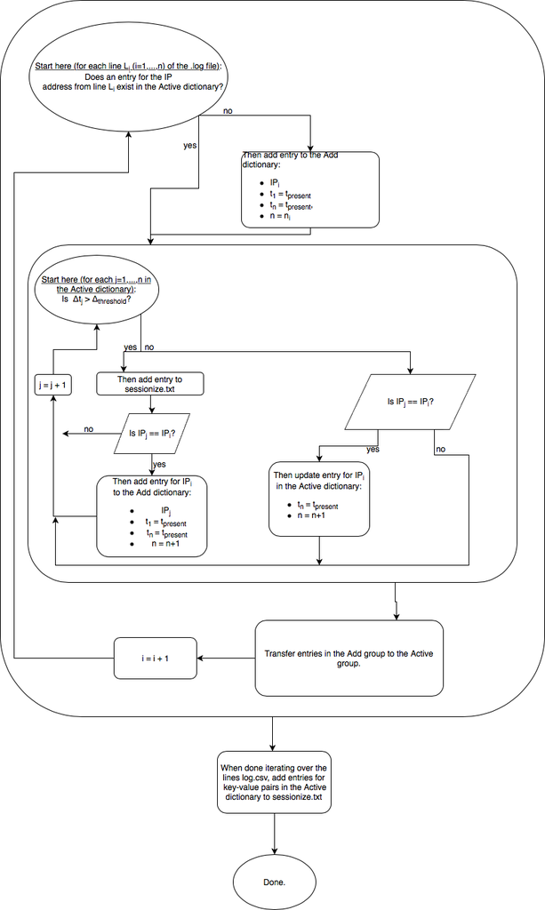

# Dependencies

The following libraries and modules are required:

```
sys
csv
datetime.dt
datetime.timedelta
```

I wrote my script in Python 3.

# Run Instructions

Run the executable `run.sh` script in the topmost folder of my submission or enter the following in the terminal:

```
python ./src/sessionization.py ./input/log.csv ./input/inactivity_period.txt ./output/sessionization.txt
```

# Conclusion

I hope I get accepted.

Have a pleasant day!